# Modelos Multiniveis ou Modelos Hierárquicos

Jose Storopoli

Modelos hierárquicos Bayesianos (também chamados de modelos multiníveis) são um modelo estatístico escrito em níveis *múltiplos* (forma hierárquica) que estima os parâmetros da distribuição posterior usando o método Bayesiano. Os submodelos se combinam para formar o modelo hierárquico, e o teorema de Bayes é usado para integrá-los aos dados observados e contabilizar toda a incerteza que está presente. O resultado dessa integração é a distribuição posterior, também conhecida como estimativa de probabilidade atualizada, à medida que evidências adicionais sobre a distribuição anterior são adquiridas.

A modelagem hierárquica é usada quando as informações estão disponíveis em vários níveis diferentes de unidades de observação. A forma hierárquica de análise e organização auxilia no entendimento de problemas multiparâmetros e também desempenha um papel importante no desenvolvimento de estratégias computacionais.

Os modelos hierárquicos são descrições matemáticas que envolvem vários parâmetros, de modo que as estimativas de alguns parâmetros dependem significativamente dos valores de outros parâmetros.

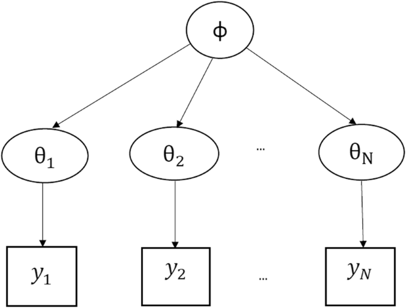

Modelo Hierarquico

## Quando usar Modelos Multiníveis?

Modelos multiníveis são particularmente apropriados para projetos de pesquisa onde os dados dos participantes são organizados em mais de um nível (ou seja, dados aninhados - *nested data*). As unidades de análise geralmente são indivíduos (em um nível inferior) que estão aninhados em unidades contextuais/agregadas (em um nível superior).

Há um pressuposto principal que não pode ser violado em modelos multiníveis que é o de **permutabilidade**. Esse pressuposto parte do princípio que os grupos são permutáveis. Se esse pressuposto é violado na sua inferência, então modelos multiníveis não são apropriados.

## Hyperprior

Como as priors dos parâmetros são amostradas de uma outra prior do hiperparâmetro (parâmetro do nível superior), as priors do nível superior são chamadas de hyperpriors. Isso faz com que estimativas de um grupo ajudem o modelo a estimar melhor os outros grupos e dando estimativas mais robustas e estáveis.

Modelos multiníveis geralmente se dividem em três abordagens:

1. *Random intercept model*: Modelo no qual cada grupo recebe uma constante (*intercept*) diferente
2. *Random slope model*: Modelo no qual cada grupo recebe um coeficiente diferente para cada variável independente
3. *Random intercept-slope model*: Modelo no qual cada grupo recebe tanto uma constante (*intercept*) quanto um coeficiente diferente para cada variável independente

### *Random Intercept Model*

A primeira abordagem é o *random intercept model* na qual especificamos para cada grupo uma constante diferente. Essas constantes são amostrada de uma hyperprior.

O pacote `rstanarm` tem as funcionalidades completas para rodar modelos multiníveis e a única coisa a se fazer é alterar a formula. Há uma segunda mudança também que não usamos mais a função `stan_glm()` mas sim a função `stan_glmer()`.

No caso de *random intercept model*, a formula a ser usada segue este padrão:

```r
y ~ (1 | group) + x1 + x2
```

### *Random Slope Model*

A segunda abordagem é o *random slope model* na qual especificamos para cada grupo um coeficiente diferente para cada variável independente. Esses coeficientes são amostrada de uma hyperprior.

No caso de *random slope model*, a formula a ser usada segue este padrão:

```r
y ~ (0 + x1 | group) + (0 + x2 | group)
```

### *Random Intercept-Slope Model*

A terceira abordagem é o *random intercept-slope model* na qual especificamos para cada grupo uma constante diferente além de coeficientes diferentes para cada variável independente. Essas constantes e coeficientes são amostrados de duas ou mais hyperpriors.

No caso de *random intercept-slope model*, a formula a ser usada segue este padrão:

```r
y ~ (1 + x1 | group) + (1 + x2 | group)
```

### Exemplo com o *dataset* `cheese`

O *dataset* [`cheese`](https://rdrr.io/cran/bayesm/man/cheese.html) possui 160 observações de avaliações de queijo. Um grupo de 10 avaliadores “rurais” e 10 “urbanos” avaliaram 4 queijos diferentes $(A,B,C,D)$ em duas amostras. Portanto $4 \cdot 20 \cdot 2 = 160$. Possui 4 variáveis:

- `cheese`: tipo do queijo $(A,B,C,D)$
- `rater`: avaliador $(1,\dots, 10)$
- `background`: origem do avaliador em “urbano” ou “rural”
- `y`: variável dependente - nota da avaliação

```r
cheese <- read.csv2("datasets/cheese.csv", stringsAsFactors = T, row.names = 1)
```

#### *Random Intercept Model*

No primeiro exemplo vamos usar um modelo que cada grupo de `cheese` recebe uma constante diferente:

```r
library(rstanarm)
random_intercept <- stan_glmer(
  y ~ (1 | cheese) + background,
  data = cheese
)
```

```
starting worker pid=18278 on localhost:11140 at 11:42:41.883
starting worker pid=18296 on localhost:11140 at 11:42:42.096
starting worker pid=18314 on localhost:11140 at 11:42:42.335
starting worker pid=18332 on localhost:11140 at 11:42:42.562
```

No sumário do modelo vemos que os avaliadores urbanos avaliam melhor os queijos que os avaliadores rurais, mas também observamos que cada queijo possui uma “taxa basal” de avaliação. Sendo $B$ o pior queijo e $C$ o melhor queijo:

```r
summary(random_intercept)
```

```
Model Info:
 function:     stan_glmer
 family:       gaussian [identity]
 formula:      y ~ (1 | cheese) + background
 algorithm:    sampling
 sample:       4000 (posterior sample size)
 priors:       see help('prior_summary')
 observations: 160
 groups:       cheese (4)

Estimates:
                                        mean   sd    10%   50%   90%
(Intercept)                            67.3    5.9  60.3  67.3  74.2
backgroundurban                         7.4    1.1   6.0   7.4   8.8
b[(Intercept) cheese:A]                 3.8    5.9  -3.1   3.8  10.8
b[(Intercept) cheese:B]               -14.2    5.9 -21.2 -14.0  -7.2
b[(Intercept) cheese:C]                 8.5    5.9   1.5   8.5  15.7
b[(Intercept) cheese:D]                 1.3    5.9  -5.7   1.4   8.4
sigma                                   7.1    0.4   6.6   7.0   7.6
Sigma[cheese:(Intercept),(Intercept)] 139.7  134.4  42.4  99.2 280.2

Fit Diagnostics:
           mean   sd   10%   50%   90%
mean_PPD 70.8    0.8 69.8  70.8  71.9

The mean_ppd is the sample average posterior predictive distribution of the outcome variable (for details see help('summary.stanreg')).

MCMC diagnostics
                                      mcse Rhat n_eff
(Intercept)                           0.2  1.0  1101
backgroundurban                       0.0  1.0  3640
b[(Intercept) cheese:A]               0.2  1.0  1087
b[(Intercept) cheese:B]               0.2  1.0  1097
b[(Intercept) cheese:C]               0.2  1.0  1104
b[(Intercept) cheese:D]               0.2  1.0  1094
sigma                                 0.0  1.0  3740
Sigma[cheese:(Intercept),(Intercept)] 3.4  1.0  1595
mean_PPD                              0.0  1.0  3993
log-posterior                         0.1  1.0  1429

For each parameter, mcse is Monte Carlo standard error, n_eff is a crude measure of effective sample size, and Rhat is the potential scale reduction factor on split chains (at convergence Rhat=1).
```

#### *Random Slope Model*

No segundo exemplo vamos usar um modelo que cada grupo de `cheese` recebe um coeficiente diferente para `background`:

```r
random_slope <- stan_glmer(
  y ~ (0 + background | cheese),
  data = cheese
)
```

```
starting worker pid=18367 on localhost:11140 at 11:43:02.180
starting worker pid=18385 on localhost:11140 at 11:43:02.494
starting worker pid=18403 on localhost:11140 at 11:43:02.821
starting worker pid=18421 on localhost:11140 at 11:43:03.081
```

Aqui vemos que todos os queijos recebem a mesma constante mas cada queijo possui um coeficiente diferente para background do avaliador:

```r
summary(random_slope)
```

```
Model Info:
 function:     stan_glmer
 family:       gaussian [identity]
 formula:      y ~ (0 + background | cheese)
 algorithm:    sampling
 sample:       4000 (posterior sample size)
 priors:       see help('prior_summary')
 observations: 160
 groups:       cheese (4)

Estimates:
                                                mean   sd    10%   50%   90%
(Intercept)                                    70.0    5.9  63.1  69.9  77.0
b[backgroundrural cheese:A]                     0.8    6.0  -6.6   0.9   7.9
b[backgroundurban cheese:A]                     8.7    6.1   1.3   8.7  15.9
b[backgroundrural cheese:B]                   -15.8    6.3 -23.4 -15.6  -8.3
b[backgroundurban cheese:B]                   -10.4    5.9 -17.4 -10.3  -3.3
b[backgroundrural cheese:C]                     5.3    5.9  -1.8   5.4  12.3
b[backgroundurban cheese:C]                    13.6    6.1   6.1  13.5  20.9
b[backgroundrural cheese:D]                    -0.7    6.0  -8.0  -0.6   6.2
b[backgroundurban cheese:D]                     5.4    6.1  -2.0   5.4  12.6
sigma                                           7.1    0.4   6.6   7.1   7.7
Sigma[cheese:backgroundrural,backgroundrural] 131.6  115.2  39.1  96.2 266.4
Sigma[cheese:backgroundurban,backgroundrural]  73.3   88.2   4.3  54.0 164.9
Sigma[cheese:backgroundurban,backgroundurban] 155.4  137.1  50.9 116.6 292.8

Fit Diagnostics:
           mean   sd   10%   50%   90%
mean_PPD 70.8    0.8 69.8  70.9  71.9

The mean_ppd is the sample average posterior predictive distribution of the outcome variable (for details see help('summary.stanreg')).

MCMC diagnostics
                                              mcse Rhat n_eff
(Intercept)                                   0.2  1.0   688
b[backgroundrural cheese:A]                   0.2  1.0   724
b[backgroundurban cheese:A]                   0.2  1.0   714
b[backgroundrural cheese:B]                   0.2  1.0   720
b[backgroundurban cheese:B]                   0.2  1.0   750
b[backgroundrural cheese:C]                   0.2  1.0   703
b[backgroundurban cheese:C]                   0.2  1.0   754
b[backgroundrural cheese:D]                   0.2  1.0   711
b[backgroundurban cheese:D]                   0.2  1.0   741
sigma                                         0.0  1.0  4109
Sigma[cheese:backgroundrural,backgroundrural] 3.0  1.0  1441
Sigma[cheese:backgroundurban,backgroundrural] 2.4  1.0  1316
Sigma[cheese:backgroundurban,backgroundurban] 4.1  1.0  1100
mean_PPD                                      0.0  1.0  3913
log-posterior                                 0.1  1.0  1154

For each parameter, mcse is Monte Carlo standard error, n_eff is a crude measure of effective sample size, and Rhat is the potential scale reduction factor on split chains (at convergence Rhat=1).
```

#### *Random Intercept-Slope Model*

No terceiro exemplo vamos usar um modelo que cada grupo de `cheese` recebe uma constanten diferente e um coeficiente diferente para `background`:

```r
random_intercept_slope <- stan_glmer(
  y ~ (1 + background | cheese),
  data = cheese
)
```

```
starting worker pid=18521 on localhost:11140 at 11:43:32.131
starting worker pid=18539 on localhost:11140 at 11:43:32.461
starting worker pid=18557 on localhost:11140 at 11:43:32.781
starting worker pid=18575 on localhost:11140 at 11:43:33.109
```

Aqui vemos que os queijos recebem a constantes diferentes e que cada queijo possui um coeficiente diferente para background do avaliador:

```r
summary(random_intercept_slope)
```

```
Model Info:
 function:     stan_glmer
 family:       gaussian [identity]
 formula:      y ~ (1 + background | cheese)
 algorithm:    sampling
 sample:       4000 (posterior sample size)
 priors:       see help('prior_summary')
 observations: 160
 groups:       cheese (4)

Estimates:
                                                mean   sd    10%   50%   90%
(Intercept)                                    65.7    7.6  56.8  65.6  74.7
b[(Intercept) cheese:A]                         5.1    7.6  -4.2   5.4  14.2
b[backgroundurban cheese:A]                     7.8    2.2   5.1   7.8  10.7
b[(Intercept) cheese:B]                       -11.1    7.9 -20.8 -10.9  -1.8
b[backgroundurban cheese:B]                     4.6    2.4   1.6   4.6   7.7
b[(Intercept) cheese:C]                         9.6    7.5   0.5   9.7  18.5
b[backgroundurban cheese:C]                     8.4    2.2   5.6   8.4  11.2
b[(Intercept) cheese:D]                         3.5    7.6  -5.7   3.7  12.5
b[backgroundurban cheese:D]                     6.0    2.1   3.3   6.0   8.7
sigma                                           7.1    0.4   6.6   7.1   7.7
Sigma[cheese:(Intercept),(Intercept)]         148.8  146.6  43.2 104.4 294.3
Sigma[cheese:backgroundurban,(Intercept)]      17.6   74.7 -50.1  14.9  93.2
Sigma[cheese:backgroundurban,backgroundurban]  85.6   85.6  25.4  60.1 170.1

Fit Diagnostics:
           mean   sd   10%   50%   90%
mean_PPD 70.8    0.8 69.8  70.8  71.9

The mean_ppd is the sample average posterior predictive distribution of the outcome variable (for details see help('summary.stanreg')).

MCMC diagnostics
                                              mcse Rhat n_eff
(Intercept)                                   0.3  1.0   754
b[(Intercept) cheese:A]                       0.3  1.0   744
b[backgroundurban cheese:A]                   0.0  1.0  4685
b[(Intercept) cheese:B]                       0.3  1.0   759
b[backgroundurban cheese:B]                   0.0  1.0  2870
b[(Intercept) cheese:C]                       0.3  1.0   798
b[backgroundurban cheese:C]                   0.0  1.0  4587
b[(Intercept) cheese:D]                       0.3  1.0   775
b[backgroundurban cheese:D]                   0.0  1.0  4847
sigma                                         0.0  1.0  4006
Sigma[cheese:(Intercept),(Intercept)]         3.4  1.0  1829
Sigma[cheese:backgroundurban,(Intercept)]     2.3  1.0  1052
Sigma[cheese:backgroundurban,backgroundurban] 1.9  1.0  2081
mean_PPD                                      0.0  1.0  4126
log-posterior                                 0.1  1.0  1001

For each parameter, mcse is Monte Carlo standard error, n_eff is a crude measure of effective sample size, and Rhat is the potential scale reduction factor on split chains (at convergence Rhat=1).
```

## Priors de Modelos Multiníveis

Relembrando a tabela de priors da Aula 4:

| **Argumento** | **Usado em** | **Aplica-se à** |
| --- | --- | --- |
| `prior_intercept` | Todas funções de modelagem exceto `stan_polr` and `stan_nlmer` | Constante (*intercept*) do modelo, após centralização dos preditores |
| `prior` | Todas funções de modelagem | Coeficientes de Regressão, não inclui coeficientes que variam por grupo em modelos multiníveis (veja `prior_covariance`) |
| `prior_aux` | `stan_glm`, `stan_glmer`, `stan_gamm4`, `stan_nlmer` | Parâmetro auxilizar (ex: desvio padrão (*standard error* - DP), interpretação depende do modelo |
| `prior_covariance` | `stan_glmer`, `stan_gamm4`, `stan_nlmer` | Matrizes de covariância em modelos multiníveis |

- Constante(*Intercept*): centralizada com média $\mu_{y_{group}}$ para cada grupo e desvio padrão de $2.5 \sigma_{y_{group}}$ para cada grupo - `prior_intercept = normal(mean_y_group, 2.5 * sd_y_group)`
- Coeficientes: aqui não especifica-se uma prior para cada coeficiente, mas sim uma prior para a **matriz de correlação** das variáveis independentes usando uma distribuição LKJ - `prior_covariance = lkj(regularization = 1, concentration = 1, shape = 1, scale = 1)`

## Atividade Prática

Para atividade prática, temos o *dataset* `rikz` em `datasets/rikz.csv`.

For each of 9 intertidal areas (denoted ‘Beaches’), the researchers sampled five sites (denoted ‘Sites’) and at each site they measured abiotic variables and the diversity of macro-fauna (e.g. aquatic invertebrates). Here, species richness refers to the total number of species found at a given site while NAP ( i.e. Normal Amsterdams Peil) refers to the height of the sampling location relative to the mean sea level and represents a measure of the amount of food available for birds, etc. For our purpose, the main question is:

**What is the influence of NAP on species richness?**

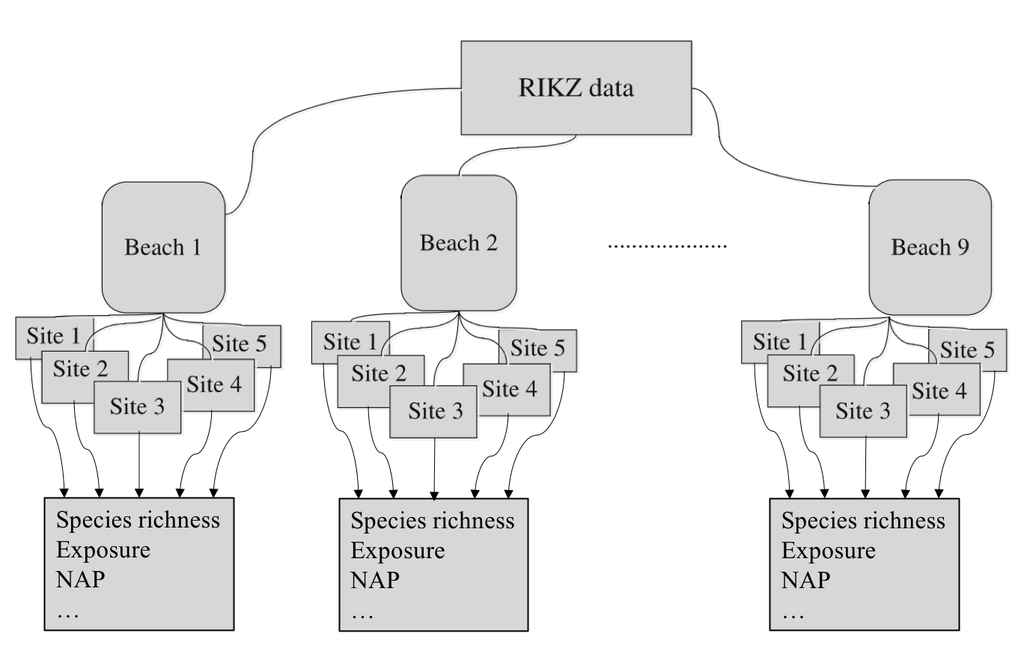

Ricz Dataset

```r
rikz <- read.csv2("datasets/rikz.csv", row.names = 1)
rikz$Beach <- as.factor(rikz$Beach)
rikz$Site <- as.factor(rikz$Site)
```